## Differences between two TV Series

The aim of this exercise is to provide basic informations about 2 TV Series and see the ratings of every single episode given by **site** users. The **site** is *http://www.imdb.com/* which contain ratings/comments/basic info of every movie or TV Series. The HTML site was parsed using **rvest** package, which is mainly used for parsing sites that doesn’t have tabular form.

The first TV Series is **Game of Thrones**, which belengs to *Adventure, Drama, Fantasy* cathegory and the overall grade is **9.5**.

Percentage distribution in **male** group:

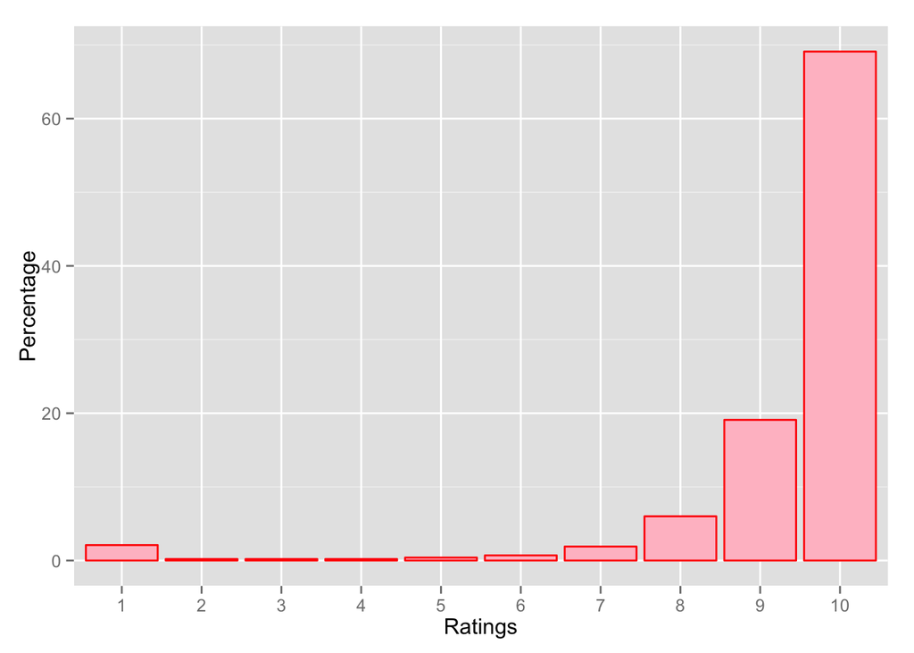

Percentage distribution in **female** group:

[figure not shown]

Percentage distribution in **both** groups:

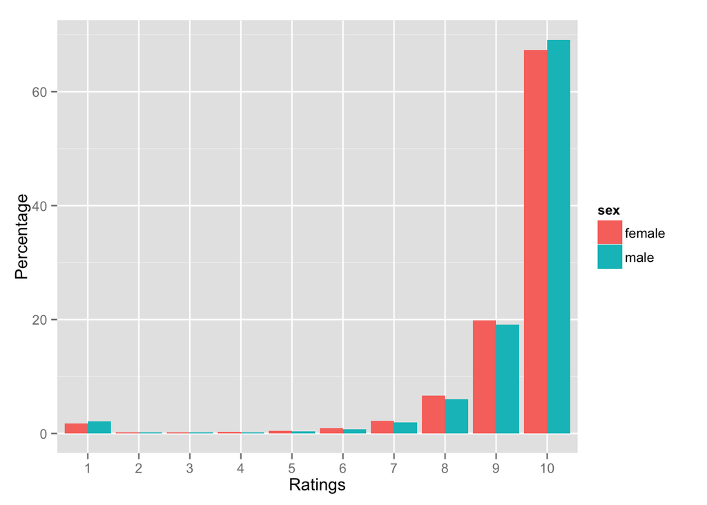

Rating for all the episodes:

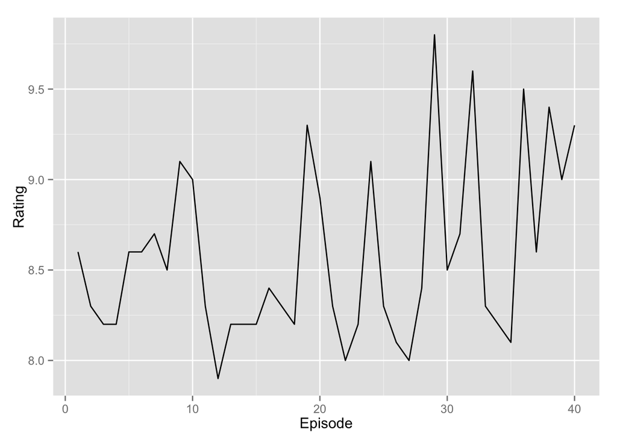

Average rating for every season:

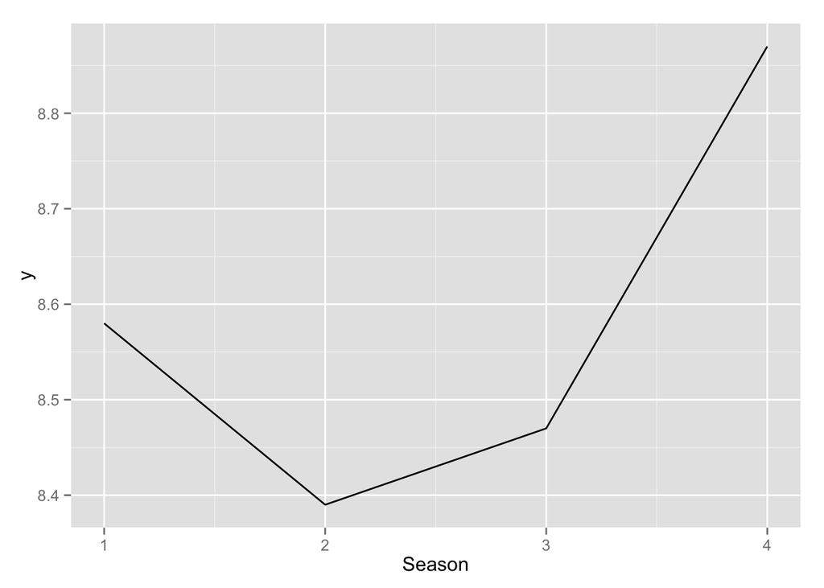

The second TV Series is **The Walking Dead**, which belengs to *Drama, Horror* cathegory and the overall grade is **8.7**.

Percentage distribution in **male** group:

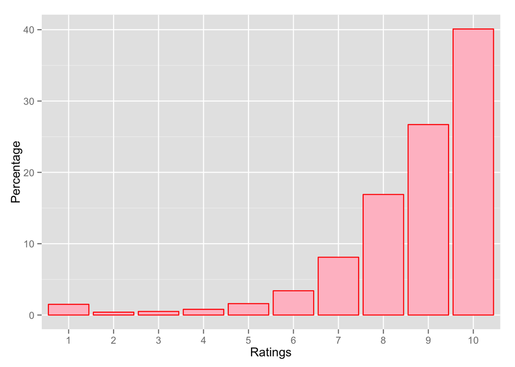

Percentage distribution in **female** group:

[figure not shown]

Percentage distribution in **both** groups:

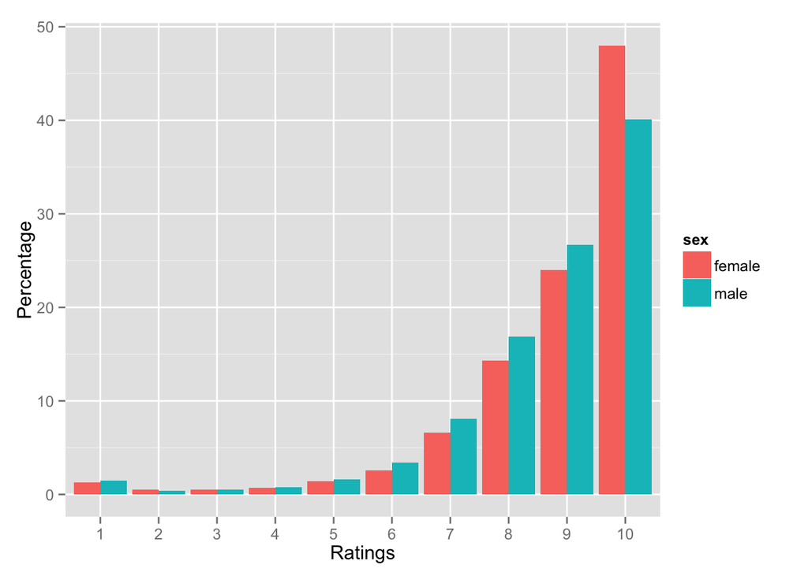

Rating for all the episodes:

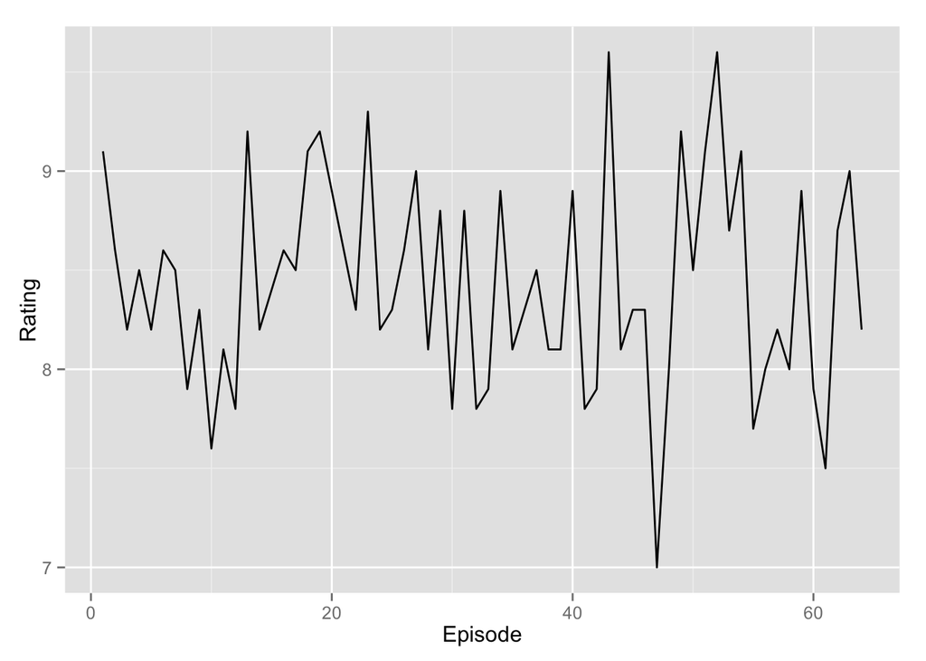

Average rating for every season:

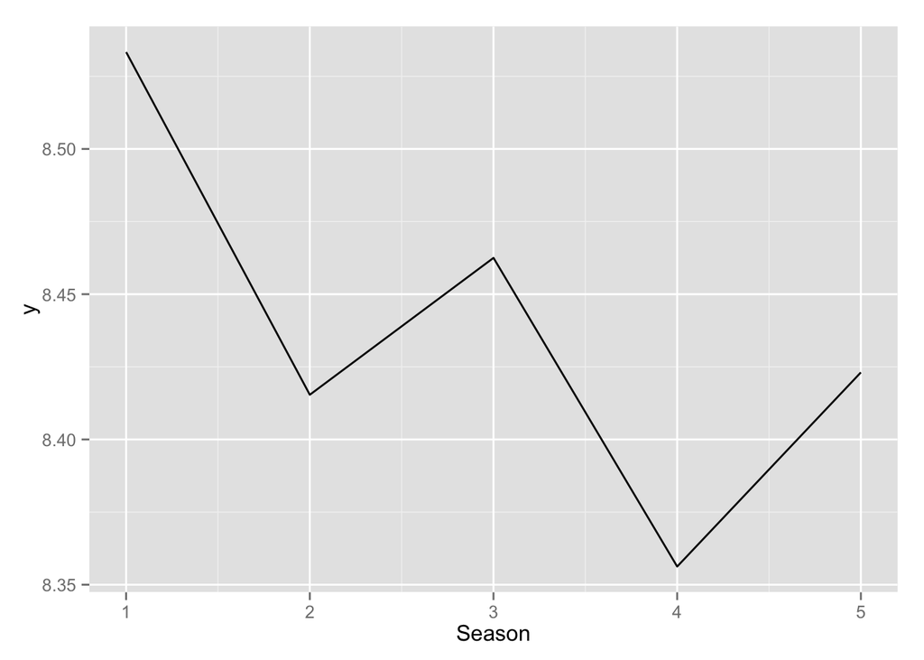